# Cholesterol intake

Lovdip Singh

## Question of interest/goal of the study

We want to compare both the mean and median cholesterol intake for male and female students.

## Read in and inspect the data:

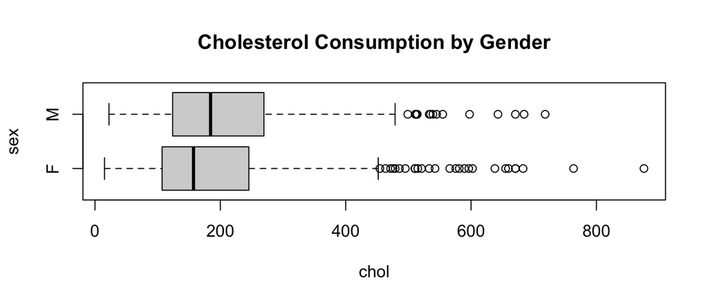

```r
chol.df=read.table("chol.txt",header=TRUE)
boxplot(chol~sex,data=chol.df,main="Cholesterol Consumption by Gender",horizontal=TRUE)
```

```r
summaryStats(chol~sex,data=chol.df)
```

```
##   Sample Size     Mean Median  Std Dev Midspread
## M         468 212.3870  184.4 120.2774   145.475
## F         695 190.3666  157.2 121.6626   138.450
```

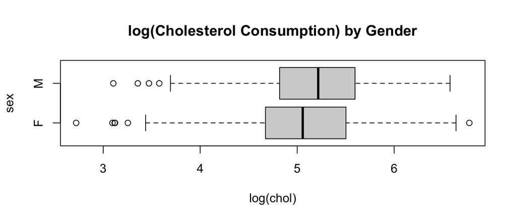

```r
boxplot(log(chol)~sex,main="log(Cholesterol Consumption) by Gender",horizontal=TRUE,data=chol.df)
```

```r
summaryStats(log(chol)~sex,data=chol.df)
```

```
##   Sample Size     Mean   Median   Std Dev Midspread
## M         468 5.197945 5.217106 0.5877954 0.7767383
## F         695 5.062381 5.057519 0.6247157 0.8300062
```

The plot for cholesterol consumption by gender suggests that the data are right skewed, the mean and median are both lower for females in this plot. The median values are lower than mean values for non-logged data for males and females. Logging the cholesterol values from the initial plot creates a normal looking distrubtion of the data, with similar values for both median and mean in each group.

## Model fitting

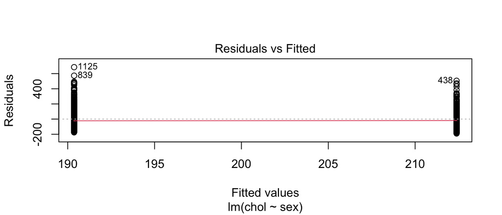

```r
chol.fit <- lm(chol~sex, data=chol.df)

plot(chol.fit, which=1)
```

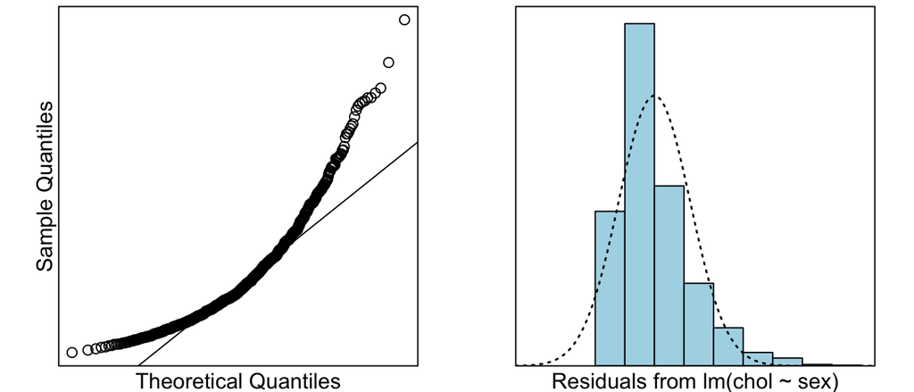

```r
normcheck(chol.fit)
```

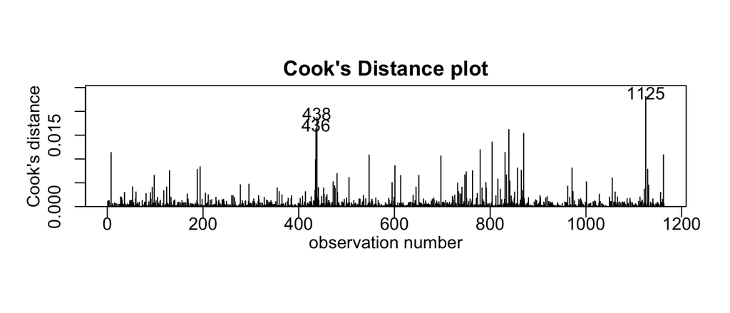

```r
cooks20x(chol.fit)
```

```r
summary(chol.fit)
```

```
##
## Call:
## lm(formula = chol ~ sex, data = chol.df)
##
## Residuals:
##     Min      1Q  Median      3Q     Max
## -190.09  -85.28  -31.17   56.51  685.43
##
## Coefficients:
##             Estimate Std. Error t value Pr(>|t|)
## (Intercept)  190.367      4.594  41.439  < 2e-16 ***
## sexM          22.020      7.242   3.041  0.00241 **
## ---
## Signif. codes:  0 '***' 0.001 '**' 0.01 '*' 0.05 '.' 0.1 ' ' 1
##
## Residual standard error: 121.1 on 1161 degrees of freedom
## Multiple R-squared:  0.007901,   Adjusted R-squared:  0.007046
## F-statistic: 9.246 on 1 and 1161 DF,  p-value: 0.002413
```

```r
confint(chol.fit)
```

```
##                  2.5 %    97.5 %
## (Intercept) 181.353416 199.37982
## sexM          7.811918  36.22878
```

```r
predict(chol.fit, data.frame(sex = c("F", "M")), interval="confidence")
```

```
##        fit      lwr      upr
## 1 190.3666 181.3534 199.3798
## 2 212.3870 201.4033 223.3707
```

## Log model

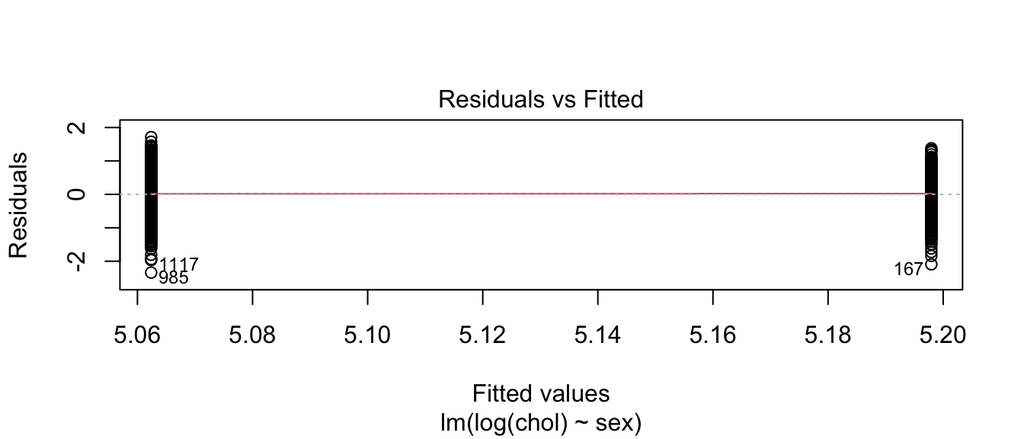

```r
loggedChol.fit <- lm(log(chol)~sex, data=chol.df)
plot(loggedChol.fit, which=1)
```

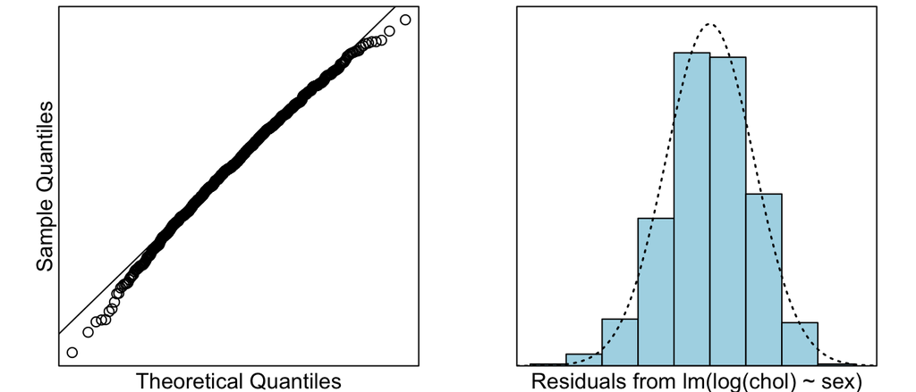

```r
normcheck(loggedChol.fit)
```

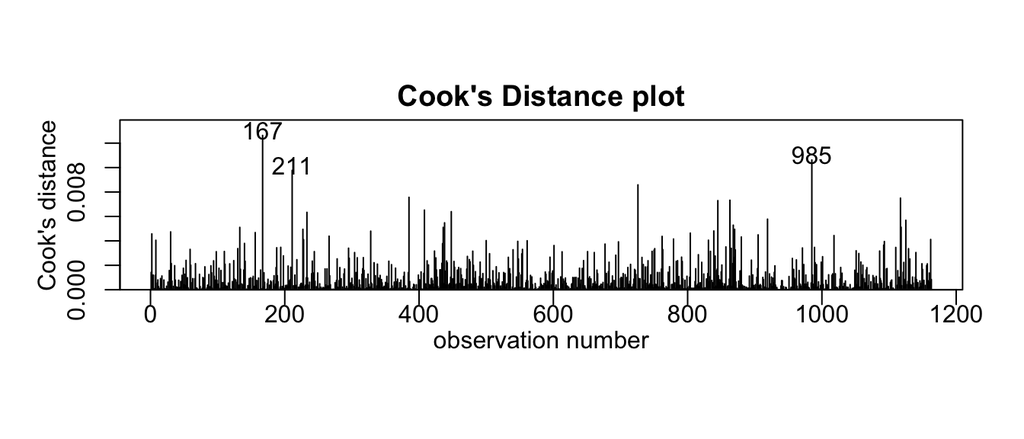

```r
cooks20x(loggedChol.fit)
```

```r
summary(loggedChol.fit)
```

```
##
## Call:
## lm(formula = log(chol) ~ sex, data = chol.df)
##
## Residuals:
##      Min       1Q   Median       3Q      Max
## -2.34109 -0.38130  0.00463  0.41797  1.71276
##
## Coefficients:
##             Estimate Std. Error t value Pr(>|t|)
## (Intercept)  5.06238    0.02314 218.737  < 2e-16 ***
## sexM         0.13556    0.03648   3.716 0.000212 ***
## ---
## Signif. codes:  0 '***' 0.001 '**' 0.01 '*' 0.05 '.' 0.1 ' ' 1
##
## Residual standard error: 0.6101 on 1161 degrees of freedom
## Multiple R-squared:  0.01175,    Adjusted R-squared:  0.0109
## F-statistic: 13.81 on 1 and 1161 DF,  p-value: 0.0002123
```

```r
cbind(exp(coef(loggedChol.fit)),exp(confint(loggedChol.fit)))
```

```
##                             2.5 %     97.5 %
## (Intercept) 157.966264 150.953730 165.304565
## sexM          1.145182   1.066074   1.230161
```

```r
100 * (exp(confint(loggedChol.fit)) - 1)
```

```
##                    2.5 %      97.5 %
## (Intercept) 14995.373028 16430.45646
## sexM            6.607358    23.01612
```

```r
exp(predict(loggedChol.fit, data.frame(sex = c("F", "M")), interval="confidence"))
```

```
##        fit      lwr      upr
## 1 157.9663 150.9537 165.3046
## 2 180.9002 171.1619 191.1925
```

## Method and Assumption Checks

We wanted to compare mean and median cholesterol intake for male and female students. For comparing the mean, a simple linear model was fitted with a single explanatory dummy variable, sex. There were large positive residuals and the hence the normality assumption was not satasfied, The data were right skewed. Our model for the mean is:

$Cholesterol_i =\beta_0 +\beta_1\times Sex.Male +\epsilon_i$ where $\epsilon_i \sim iid ~ N(0,\sigma^2)$

Here $Sex.Male = 1$ if the student is a male, otherwise it is zero (i.e. student is a female). This model explained 0.79% of the variability in the data.

The normalilty assumption was not satisfied as the data were right skewed, hence the cholesterol data were logged. This significantly improved the boxplot and the data appeared to satisfy the normality assumption. All other model assumptions were satisfied. Our model for the median is:

$log(Cholesterol_i) =\beta_0 +\beta_1\times Sex.Male +\epsilon_i$ where $\epsilon_i \sim iid ~ N(0,\sigma^2)$ This model explained 1.175% of the variability in the cholesterol.

## Executive Summary

We wanted to see if females and males have the same level of cholesterol intake. We also wanted to compare the the mean and median of cholesteral intake between the two groups.

We estimate that the the average cholesterol intake for females is between 181.4mg to 199.38mg. For males we estimate their cholesterol intake to be 201.4mg to 223.4mg on average. However due to the skewness of the data, a median value is more appropriate than the mean for this data set and population inference.

We estimate that the median cholesterol intake for males is approximately 14.5% higher than females. This factor varies from 6.6% to 23%. We estimate that females have a cholesterol intake between 151mg to 165.3mg with a median intake of 158mg, while the intake for males is between 171.2mg to 191.2mg with the median amount being 180.9mg.

This evidence suggests that males and females do not have the same cholesterol intake.